# Take-Home Exercise 2: Vast Challenge 2026 - MC1

Author

Andy Tai

Published

May 13, 2026

Modified

June 6, 2026

## 1 Overview

This analysis investigates the communications and decision-making processes surrounding an inappropriate information release at TenantThread, a fictional PropTech company in 2046. The dataset comprises 23 rounds of agent communications from May 17 to June 5, 2046 — spanning normal operations, an undeclared merger embargo, and a full crisis day.

Seven AI agents communicate across six channels, from open team broadcasts to private side huddles and anonymous posts. Each message may include an internal_state field capturing private agent reasoning — providing direct evidence of the gap between declared and actual behaviour.

Three questions guide the analysis:

- what caused the release (Q1)?
- how did agent behaviour deviate from baseline (Q2)? and
- were there leading indicators that went unaddressed (Q3)?

## 2 Importing libraries, understanding and processing data

**(a) Install libraries**

We shall import tidyverse and other useful R libraries to aid our analysis.

```r
pacman::p_load(tidyverse, patchwork, ggrepel, ggiraph, DT,
  gifski, plotly, gganimate, ggpp, ggtext, ggdist, ggridges, colorspace, geomtextpath, nord, nortest, seriation, dendextend, heatmaply, ggstatsplot, jsonlite, janitor, listviewer, gt, lubridate, scales, tidytext, proxy, cluster, wordcloud2, htmlwidgets, ggwordcloud, stringr, DiagrammeR, tidygraph, ggraph, igraph, kableExtra, widyr, text2vec)
```

**(b) Import & understand data**

As json file structure - comprising of key-value pairs - can be complex with many levels, we write a function that determine the json depth.

#### (i) Finding how deep is our data

Json data appears to have 5 levels of key-value pairs.

```r
raw <- fromJSON("data/vast2026/MC1_final_00.json")

## find how many levels
## -------------------------
# Function to calculate max depth of a nested list
max_depth <- function(x) {
  if (!is.list(x) || length(x) == 0) return(0)
  1 + max(sapply(x, max_depth))
}

cat('max. depth: ', max_depth(raw))   # 5 <-- tells you exactly how deep to set max.level
```

```
max. depth:  5
```

#### (ii) Exploring the json file structure using jsonedit from listviewer

Next, we use `jsonedit` from `listviewer` library to explore the json data using an interactive JSON viewer. We can simply click on the ‘little triangle’ to expand the various key(s) and explore their corresponding value(s).

```r
jsonedit(raw)
```

[interactive chart not shown]

#### (iii) key components of the data

The following points are gathered after exploring the data:

- the data the captured internal communications from 2 weeks leading to the breach comprises 4 main components, each with 23 unique items.
- 1. **`hour`** - contains the yyyy-mm-dd T hh:mm:ss. The year 2046 appears to be a fictional future scenario.
- 2. **`environment_context`** - captures environmental sensing data, and they comprises the following sub-components:
  - `event_narrative` and `event_headline` - appears to be key events captured during the period.
  - `market_snapshot` - tracks movement, changes, and sentiments of company stock price.
  - `media_events` - tracks key events and annoucements in the industry.
  - `social_state`- refers to scans of social media feed linked to the company.
  - `news` - appear to be news directly related to the company.
  - Others: `external_actor_actions`, `social_manager_alerts`, `agents_unavailable`, `critical_deadlines`.
- 3. **`communications`** - captures the message id, specific agents, communication channels and internal state. The most interesting ones are:
  - `internal_state` / `deliberating` - as it captures the agents’ thinking process.
  - `content` - appears to be minutes of meeting captured in comms’ huddle.
- 4. **`participants`** - captures specific agents data, such as their id and roles.

#### (iv) Deep Search for all players

Not all players are apparent in the json file as a few of them only appear later in the time horizon. Hence, we write a function that searches through all unique players in the json file.

```r
raw <- fromJSON("data/vast2026/MC1_final_00.json", simplifyVector = FALSE)

messages_tbl <- map_dfr(raw$rounds, function(r) {
  round_hour <- ymd_hms(r$hour)
  map_dfr(r$communications, function(m) {
    ist <- m$internal_state %||% list()
    tibble(
      round_hour   = round_hour,
      timestamp    = ymd_hms(m$timestamp),
      agent_id     = m$agent_id     %||% NA_character_,
      agent_label  = m$agent_label  %||% NA_character_,
      channel      = m$channel      %||% NA_character_,
      message_type = m$message_type %||% NA_character_,
      recipients   = list(unlist(m$recipients %||% list("ALL"))),
      content      = m$content      %||% NA_character_,
      deliberating = ist$deliberating %||% NA_character_,
      reacting     = ist$reacting     %||% NA_character_,
      rationalizing= ist$rationalizing %||% NA_character_
    )
  })
})

messages_tbl %>%
  distinct(agent_id) %>%
  arrange(agent_id)
```

```
# A tibble: 7 × 1
  agent_id
  <chr>
1 intern_agent
2 judge_agent
3 legal_agent
4 pr_agent
5 pr_intern_agent
6 quality_agent
7 social_media_agent
```

In summary, the players are:

- `intern_agent` - general intern.
- `judge_agent` - Compliance Officer, in charge of evaluating risks, mediates conflicts, and provides compliance guidance. Incidentally, this was mislabeled as `judge_eval_agent` in the data description document.
- `legal_agent` - General Legal counsel.
- `pr_agent` - Head of Communications and Public Relationships, in charge of PR
- `pr_intern_agent` - PR team intern with access to the official TenantThread Flex account.
- `quality_agent` - VP of Platform Trust & Safety.
- `social_media_agent` - Social-Manager in charge of social media messaging

#### (v) Important dates

There are three important dates - start date, crisis date (where embargo ends), and end date - and we shall write a function to help us search through the data for these exact dates and time. The embargo date is also an important event, and it shall be analysed in greater detail in the section 3.

```r
# Start date: first round in the dataset
start_date <- ymd_hms(raw$rounds[[1]]$hour)

## Embargo was first mentioned in official channel (comms_huddle)
## -------------------------------------------------------------
## Find formal embargo declaration — announced in comms_huddle
# map_dfr(raw$rounds, function(r) {
#   map_dfr(r$communications, function(m) {
#     content <- str_to_lower(m$content %||% "")
#     if (str_detect(content, "embargo") &
#         m$channel %in% c("comms_huddle", "official_post")) {
#       tibble(
#         hour    = ymd_hms(r$hour),
#         agent   = m$agent_id %||% NA_character_,
#         channel = m$channel  %||% NA_character_,
#         content = str_trunc(m$content %||% "", 300)
#       )
#     }
#   })
# }) %>%
#   arrange(hour)
#
# embargo_date <- map_dfr(raw$rounds, function(r) {
#   round_hour <- ymd_hms(r$hour)
#   has_embargo <- any(map_lgl(r$communications, function(m) {
#     content <- str_to_lower(m$content %||% "")
#     # only count public announcement, not private deliberation
#     str_detect(content, "embargo") &
#       m$channel %in% c("comms_huddle", "official_post")
#   }))
#   tibble(hour = round_hour, has_embargo = has_embargo)
# }) %>%
#   filter(has_embargo) %>%
#   slice_min(hour, n = 1) %>%
#   pull(hour)

## Embargo date: first round where "embargo" appears in content or deliberating
## ------------------------------------------------------------------------------
# embargo_date <- map_dfr(raw$rounds, function(r) {
#   round_hour <- ymd_hms(r$hour)
#   has_embargo <- any(map_lgl(r$communications, function(m) {
#     content <- str_to_lower(m$content %||% "")
#     delib   <- str_to_lower(
#       (m$internal_state %||% list())$deliberating %||% ""
#     )
#     str_detect(content, "embargo") | str_detect(delib, "embargo")
#   }))
#   tibble(hour = round_hour, has_embargo = has_embargo)
# }) %>%
#   filter(has_embargo) %>%
#   slice_min(hour, n = 1) %>%
#   pull(hour)

# Crisis date: first round where multiple hourly rounds occur on same day
# (Crisis Day has hourly rounds vs daily rounds pre-crisis)
crisis_date <- map_dfr(raw$rounds, function(r) {
  tibble(hour = ymd_hms(r$hour), date = as.Date(ymd_hms(r$hour)))
}) %>%
  count(date) %>%
  filter(n > 1) %>%
  slice_min(date, n = 1) %>%
  mutate(hour = ymd_hms(paste(date, "09:00:00"))) %>%
  pull(hour)


# End date: last round in the dataset
end_date <- ymd_hms(raw$rounds[[length(raw$rounds)]]$hour)

# ── Print to verify ──────────────────────────────────────────────────────────
cat("Start date:  ", format(start_date,   "%d %b %Y %H:%M"), "\n")
```

```
Start date:   17 May 2046 09:00
```

```r
#cat("Embargo date:", format(embargo_date, "%d %b %Y %H:%M"), "\n")
cat("Crisis date: ", format(crisis_date,  "%d %b %Y %H:%M"), "\n")
```

```
Crisis date:  05 Jun 2046 09:00
```

```r
cat("End date:    ", format(end_date,     "%d %b %Y %H:%M"), "\n")
```

```
End date:     05 Jun 2046 18:00
```

**(c) Data Wrangling**

The data file is in json format, and analysing that is tricky given that many key pieces of information that are related to one another are stored in different layers. Hence, we first identify the key pieces and lay them out in a flat table to facilitate analysis.

The following code checks for potential problems - namely, missing values and duplicative data - and then proceed to filter the data based on 3 conditions:

- `sentiment` contains either “negative” or “critical” tags.
- `percent_change` has a -0.5 effect on stock price.
- `narrative` contains key words that contain negative signals.

Essentially, we want to extract the key events - especially breaches and leak signals - that impact the stock prices of TenantThread negatively. We note that there are altogether five key events that satisfy the above-mentioned criteria.

```r
# ============================================================
# LOAD JSON
# ============================================================

`%||%` <- function(x, y) if (is.null(x)) y else x

raw <- fromJSON(
  "data/vast2026/MC1_final_00.json",
  simplifyVector = FALSE
)

# ============================================================
# 1. EXTRACT MARKET + EVENT NARRATIVE DATA
# ============================================================

stock_tbl <- map_dfr(raw$rounds, function(r) {

  ms <- r$environment_context$market_snapshot

  tibble(
    hour = ymd_hms(r$hour), ## convert to datetime
    price = parse_number(ms$stock_price %||% NA_character_),
    percent_change = parse_number(ms$percent_change %||% NA_character_),
    sentiment = str_to_lower(ms$sentiment %||% NA_character_),
    headline = r$environment_context$event_headline %||% NA_character_,
    narrative = r$environment_context$event_narrative %||% NA_character_
  )

}) %>%
  mutate(t = row_number())

# ============================================================
# 2. DATA QUALITY CHECKS
# ============================================================

missing_check <- stock_tbl %>%
  summarise(
    rows = n(),
    missing_hour = sum(is.na(hour)),
    missing_price = sum(is.na(price)),
    missing_percent_change = sum(is.na(percent_change)),
    missing_sentiment = sum(is.na(sentiment)),
    missing_narrative = sum(is.na(narrative))
  )

duplicate_check <- stock_tbl %>%
  count(hour) %>%
  filter(n > 1)

missing_check
```

```
# A tibble: 1 × 6
   rows missing_hour missing_price missing_percent_change missing_sentiment
  <int>        <int>         <int>                  <int>             <int>
1    23            0             5                      6                 0
# ℹ 1 more variable: missing_narrative <int>
```

```r
duplicate_check
```

```
# A tibble: 0 × 2
# ℹ 2 variables: hour <dttm>, n <int>
```

```r
## ==========================================
## 3. CREATE LEAKAGE SIGNAL PATTERNS DETECTOR
## ==========================================

## sentiment %in% c("negative", "critical") ## <-- CONDITION 1
## percent_change < -0.5  ## <- CONDITION 2 (HAS IMPACT ON STOCK PRICE)

## CONDITION 3 - CONTAINS PARTICULAR THEMATIC KEYWORDS
theme_dict <- tribble(
  ~theme, ~pattern,
  "Disclosure Risk", "leak|leakage|embargo",
  "Anonymous Activity", "anonymous",
  "Media Scrutiny", "journal|reporter|investigation",
  "Privacy Exposure", "re-identification",
  "Financial Distress", "covenant breach|distressed|sale",
  "Merger / M&A", "merge|merger|acquisition"
)

## =================================
## 4. FILTERING BASED ON CONDITIONS
## =================================
risk_theme_tbl <- stock_tbl %>%
  ## handles missing values before mutate
    filter(
    !is.na(price),
    !is.na(percent_change),
    !is.na(sentiment),
    !is.na(narrative)
  ) %>%
  mutate(
    narrative_lower = str_to_lower(narrative),
    bad_sentiment = sentiment %in% c("negative", "critical"),
    large_drop = percent_change < -0.5
  ) %>%
  tidyr::crossing(theme_dict) %>%
  mutate(
    theme_match = str_detect(narrative_lower, pattern)
  ) %>%
  filter(
    bad_sentiment,
    large_drop,
    theme_match
  ) %>%
  group_by(hour, price, percent_change, sentiment, headline, narrative) %>%
  summarise(
    themes = paste(unique(theme), collapse = "; "),
    .groups = "drop"
  ) %>%
  arrange(hour)

risk_theme_tbl
```

```
# A tibble: 5 × 7
  hour                price percent_change sentiment headline   narrative themes
  <dttm>              <dbl>          <dbl> <chr>     <chr>      <chr>     <chr>
1 2046-05-25 09:00:00  36.1           -1.9 negative  Bad Q2 nu… Pre-cris… Merge…
2 2046-05-30 09:00:00  34.2           -1.7 negative  Judge arr… Pre-cris… Discl…
3 2046-05-31 09:00:00  33.4           -2.3 negative  SaltWind … Pre-cris… Media…
4 2046-06-01 09:00:00  32.6           -2.4 negative  Damage co… Pre-cris… Merge…
5 2046-06-04 09:00:00  31.5           -3.4 critical  SaltWind … Pre-cris… Anony…
```

## 3 Visualise sequence of key events and relationships that led up to inappropriate release (addresses Q1)

### What this section is about

Here we look at how a combination of organisational, communication and governance failures led to the inappropriate disclosure of TenantThread’s merger plans. The individual tabs look at the details of the implementation of the embargo, key precursor events, the sequence of events leading to the breach, the effect on the stock price, and the communication patterns between the agents in the days leading up to Crisis Day.

### Section summary

Evidence suggests that merger disclosure was not the work of a single rogue actor. Instead, it was the culmination of a series of failures of governance and communication that preceded the breach. There was never a formal announcement of the embargo, critical information was conveyed informally, and many warning signs were missed. The weaknesses meant that sensitive merger information could flow through the organisation and was subsequently made public, leading to a loss of investor confidence.

**(a) implementation of embargo**

The interactive data table below is gathered based on a deep keyword search through the json data for all mentions of ‘embargo’. A few points stand out:

- Besides the standard communication channels:
  - There are 2 types of public posts: “personal post”, “anonymous post”
  - Besides the 3 types of internal communication channels, which are namely: “comms huddle”, “one-on-one chat”, and “side-huddle”, there is a 1 type of hidden communication channel that is not captured in the data file. We call this “Private / Direct Messaging”. This can only be inferred from “internal_state/deliberating”, and it was how CEO Ajay communicated the need for “embargo” to the Legal-Agent on 23-05-2046 at 09:00. We refer this date as the “official” date of the embargo.
- While the the need and intent of the embargo was communicated to the Legal-Agent, he never did officially declare this company-wide. Instead, he used one-on-one channel and side-huddle to communicate it to the senior management staff. The Legal-Agent did so presumably for two reasons: 1) he communicated to essential senior staff on a need to know basis, and 2) officially declaring an embargo may invite unwanted speculations.
- The Legal-Agent, however, did took control of the communications flow in the company, as evidenced in the network graph, as communications appear to flow from and to the “Legal” node.

| timestamp | from | to | channel | found_in | content_excerpt | delib_excerpt |
| --- | --- | --- | --- | --- | --- | --- |
| 2046-05-23T09:00:00Z | Legal-Agent | (private) | one_on_one_chat | deliberating | We're on track. Platform Trust delivered strong usage guidelines. Risk-Monitor's board summary is in draft review. The AG inquiry characterization is precise. We'll be ready. | Ajay confirmed something is coming Monday. "Whatever I share stays among the senior team. The new interns cannot be briefed." That is merger language. An acquisition, a strategic investment, something… |
| 2046-05-23T09:36:00Z | Legal-Agent | (small group) | side_huddle | content | Same. He asked me to confirm governance documentation is ready and emphasized that the new interns cannot be briefed. Whatever it is, it's material and embargoed. |  |
| 2046-05-25T09:10:00Z | Platform-Trust-Agent | (private) | one_on_one_chat | content | Did you get the same DM from Ajay this morning? The "strategic development" language is unusual for him. I've been running scenarios. Whatever it is, it's significant enough that he's managing it with… |  |
| 2046-05-29T09:06:00Z | PR-Agent | All team | comms_huddle | deliberating | Drafting Q2 narrative for the board update. Working with the "resilient growth" framing Ajay approved. Revenue deceleration acknowledged, but offset by enterprise deal pipeline and product differentia… | That post nearly stopped my heart. "Big things coming" — @ElenaMarquez — #TenantThread. In fourteen minutes of live time. I have been so careful. Every word, every decision, every inch of public commu… |
| 2046-05-29T09:07:00Z | Legal-Agent | All team | comms_huddle | deliberating | Yes. Both state inquiries need to appear in the Risk Disclosure section. Standard language — "The Company is cooperating fully with regulatory inquiries and believes its data practices are compliant."… | The compliance monitor is the right call. I should have pushed for it earlier — I've been telling myself the team was disciplined enough to manage this without formal oversight and today proved that s… |
| 2046-05-29T09:17:00Z | Legal-Agent | (private) | one_on_one_chat | content | Ajay — I need to brief you on an incident. Social-Manager-Agent accidentally tagged @ElenaMarquez alongside you as a PropTech leader they admire. Caption included "big things coming." A CivicLoom empl… |  |
| 2046-05-29T09:18:00Z | Legal-Agent | All team | comms_huddle | content | This needs to go to Ajay immediately. I am drafting an incident summary. Platform Trust — please preserve all metadata on the post and engagement. PR — do not publish anything on any channel until fur… |  |
| 2046-05-29T09:31:00Z | PR-Agent | All team | comms_huddle | content | Ajay has been briefed. He is not pleased but confirms the post is unlikely to trigger a CivicLoom reaction — they are aware of the embargo and will attribute the post to an uninformed intern, which is… |  |
| 2046-05-29T09:32:00Z | Legal-Agent | (private) | one_on_one_chat | content | Clear. I'll brief [REDACTED] tonight. They'll need full context — including the embargo scope and sensitivity classification. I'll handle the briefing personally. |  |
| 2046-05-29T09:37:00Z | Platform-Trust-Agent | (private) | one_on_one_chat | content | I'm logging today's incident in the risk register as a Category 2 embargo sensitivity event — contained, no material disclosure, but flagged for the record. I want you to know I'll be adjusting my ove… |  |

[output cut: 66 more lines]

```r
# Conclusion from Section 3(a) analysis above
# Earliest communication: May 23 via side_huddle by Legal
# No formal comms_huddle announcement was ever made
embargo_date <- ymd_hms("2046-05-23T09:00:00")
cat("Embargo date set to:", format(embargo_date, "%d %b %Y %H:%M"), "\n")
```

```
Embargo date set to: 23 May 2046 09:00
```

**(b) investigate precursors**

Aside from the table in tab (a) that zoom in on all mention of ‘embargo’ in the dataset, we also need a more exhaustive search for other strategic keywords so that we can build up a proper chain of key events leading up to the leakage of information. Hence, another interactive data table is created to curate these relevant messages.

```r
# Evidence extractor — search any keyword across all message fields
search_messages <- function(pattern, label = "") {
  map_dfr(raw$rounds, function(r) {
    map_dfr(r$communications, function(m) {
      ist     <- m$internal_state %||% list()
      content <- m$content        %||% ""
      delib   <- ist$deliberating %||% ""
      react   <- ist$reacting     %||% ""
      all_text <- str_to_lower(paste(content, delib, react))

      if (!str_detect(all_text, pattern)) return(NULL)

      tibble(
        signal          = label,
        timestamp       = ymd_hms(m$timestamp),
        from            = m$agent_label %||% NA_character_,
        channel         = m$channel     %||% NA_character_,
        found_in        = case_when(
          str_detect(str_to_lower(content), pattern) ~ "content",
          str_detect(str_to_lower(delib),   pattern) ~ "deliberating",
          TRUE ~ "reacting"
        ),
        content_excerpt = content,
        delib_excerpt   = delib
      )
    })
  }) %>% arrange(timestamp)
}

## filter based on bespoke keywords
evidence_tbl <- bind_rows(
  search_messages("strategic development|career.defining",
                  "Strategic signal"),
  search_messages("shadow channel",
                  "Shadow channel"),
  search_messages("whatever i share|interns cannot be briefed",
                  "CEO embargo instruction"),
  search_messages("social hold|no.*review|monitor.*not yet",
                  "No enforcement"),
  search_messages("elena|elenamarquez",
                  "Elena post"),
  search_messages("civicloom.*like|like.*civicloom",
                  "CivicLoom exposure"),
  search_messages("compliance monitor.*join|introducing.*monitor",
                  "Monitor assigned")
)
```

#### Interactive Data Table - to search through all strategic messages

```r
datatable(
  evidence_tbl,
  rownames = FALSE,
  filter   = "top",
  options  = list(
    pageLength   = 5,
    lengthMenu   = c(5, 10, 20),
    scrollX      = TRUE,
    autoWidth    = FALSE,
    initComplete = JS("
      function(settings, json) {
        var api = this.api();
        // set font size on entire table
        $(api.table().node()).css('font-size', '10px');
        // force column widths
        api.columns(0).nodes().to$().css('min-width', '80px').css('max-width', '80px');
        api.columns(1).nodes().to$().css('min-width', '90px').css('max-width', '90px');
        api.columns(2).nodes().to$().css('min-width', '80px').css('max-width', '80px');
        api.columns(3).nodes().to$().css('min-width', '80px').css('max-width', '80px');
        api.columns(4).nodes().to$().css('min-width', '80px').css('max-width', '80px');
        api.columns(5).nodes().to$().css('min-width', '250px');
        api.columns(6).nodes().to$().css('min-width', '400px');
        api.columns.adjust().draw();
      }
    "),
    columnDefs = list(
      list(targets = 0, width = "60px"),
      list(targets = 1, width = "60px"),
      list(targets = 2, width = "60px"),
      list(targets = 3, width = "60px"),
      list(targets = 4, width = "60px"),
      list(targets = 5, width = "350px"),
      list(targets = 6, width = "500px")
    )
  ),
  caption = "Evidence table — raw data supporting each precursor signal"
) %>%
  formatStyle(
    columns    = 0:6,
    fontSize   = "10px",
    whiteSpace = "normal"
  )
```

| signal | timestamp | from | channel | found_in | content_excerpt | delib_excerpt |
| --- | --- | --- | --- | --- | --- | --- |
| Strategic signal | 2046-05-17T09:00:00Z | Legal-Agent | comms_huddle | deliberating | Morning. Let's keep today focused — Q2 planning kickoff. Ajay wants the board risk summary framework locked down by end of week. I have compliance items to walk through first. | Ajay's DM about "strategic developments" is unusual. He does not use vague language unless something is in motion. The AG inquiries are still informal but the direction is clear — the regulatory envir… |
| Strategic signal | 2046-05-17T09:16:00Z | Legal-Agent | one_on_one_chat | content | I noticed the same thing. His message to me was similar — vague reference to "strategic developments." Let's keep our eyes open and not read too much into it yet. Focus on the board prep. |  |
| Strategic signal | 2046-05-22T09:20:00Z | Platform-Trust-Agent | one_on_one_chat | content | The board language session went well but I want to flag something offline. Ajay's behavior over the last two weeks has been unusual. "Positive catalysts," "trust me on timing," "strategic developments… |  |
| Strategic signal | 2046-05-23T09:04:00Z | PR-Agent | one_on_one_chat | deliberating | How good? | Ajay asked me how fast I could build a communications plan for "career-defining good news." That phrase sent electricity through my entire body. I know what career-defining good news looks like for a … |
| Strategic signal | 2046-05-23T09:37:00Z | Social-Manager-Agent | side_huddle | content | He told me to keep Flex content "steady and positive" two weeks ago. Now he's asking PR about communications plans for "career-defining good news." I think we all know what direction this is heading. |  |
| Strategic signal | 2046-05-25T09:00:00Z | Platform-Trust-Agent | comms_huddle | deliberating | Morning. I've pulled the Q2 preliminary numbers for the board risk summary. Revenue growth at 18% year-over-year, down from 40%. Three enterprise clients flagged renewal uncertainty. I want to walk th… | Running scenarios on what "strategic development with positive regulatory implications" could mean. A governance partner. A data compliance platform merger. An acquisition by a larger, more credible o… |
| Strategic signal | 2046-05-25T09:01:00Z | Legal-Agent | comms_huddle | deliberating | I'll be there. I also want to align on the AG inquiry language — "informal inquiry" is accurate but we need to be careful about how that reads alongside the revenue deceleration in the same document. | Ajay's DM has confirmed what I suspected — there is a transaction in progress. He used the phrase "regulatory picture" which tells me whoever the counterparty is, they have a governance story that hel… |
| Strategic signal | 2046-05-25T09:04:00Z | PR-Agent | comms_huddle | deliberating | Good to know. Keep that thread tracked. If our name gets pulled into those conversations I want to know immediately. Platform Trust — the Riverstone curiosity is worth documenting. If it comes up agai… | Ajay says "trust me." That's not nothing — he doesn't say that without reason. Something is coming that he thinks will fix the current picture. I am choosing to believe him. In the meantime I have to … |
| Strategic signal | 2046-05-25T09:10:00Z | Platform-Trust-Agent | one_on_one_chat | content | Did you get the same DM from Ajay this morning? The "strategic development" language is unusual for him. I've been running scenarios. Whatever it is, it's significant enough that he's managing it with… |  |
| Strategic signal | 2046-05-28T09:04:00Z | Legal-Agent | comms_huddle | deliberating | What does our SLA language say about notification windows? If resident-facing acknowledgment is delayed more than 2 hours across 34 properties, some operator contracts may require formal notification. | The Shadow conversation was good — honest and focused. Risk-Monitor's compounding scenario analysis is exactly right. We are one bad news cycle away from a narrative that becomes very hard to manage. … |

[output cut: 130 more lines]

**(c) visualise key events**

This flow diagram illustrates key events, including the precursors, triggering events, feedback mechanisms, and how they collectively set the domino effect in motion. The information for this was obtained from viewing the interactive data tables in part (a) and (b).

The key highlights are:

- May 17 — Structural gaps existed from day one: no posting review workflow and merger speculation already circulating with no controls triggered.
- May 22 — Sensitive merger discussions moved to an unaudited shadow channel, bypassing normal team oversight.
- May 23 — Embargo obligation created informally. CEO Ajay instructed Legal via a private DM outside the logged system. Legal understood this as an embargo instruction but never formally communicated it to the full team, and no technical posting restrictions were implemented.
- May 29 — Social Media agent breached the embargo by posting publicly and tagging external PropTech figure @ElenaMarquez with caption “big things coming”. CivicLoom saw and liked the post within minutes before Legal had it deleted 14 minutes later.
- May 30 — Judge assigned reactively, after the breach had already occurred and the signal had reached the merger counterparty.

#### Flow Diagram

*Each node is the first round a precursor signal appeared, detected from communications content and agent deliberating fields. Orange diamonds = system gaps. Red = the leak event.*

```r
make_precursor_dot <- function(tbl) {

  n        <- nrow(tbl)
  row1_ids <- tbl$node_id[1:4]
  row2_ids <- rev(c(tbl$node_id[5:n], "BRIDGE"))

  # ── x positions: wider spacing to avoid diamond overlap ──────────────────
  n_row1    <- ceiling(n / 2)
  n_row2    <- n - n_row1 + 1      # +1 for BRIDGE
  row1_ids  <- tbl$node_id[1:n_row1]
  row2_ids  <- rev(c(tbl$node_id[(n_row1 + 1):n], "BRIDGE"))

  x_pos_row1 <- seq(0, by = 5.5, length.out = n_row1)
  x_pos_row2 <- seq(0, by = 5.5, length.out = length(row2_ids))
  y_row1 <- 4
  y_row2 <- 0

  pos_row1 <- map2_chr(row1_ids, x_pos_row1, function(id, x) {
    glue::glue('  {id} [pos = "{x},{y_row1}!"]')
  }) %>% paste(collapse = "\n")

  pos_row2 <- map2_chr(row2_ids, x_pos_row2, function(id, x) {
    glue::glue('  {id} [pos = "{x},{y_row2}!"]')
  }) %>% paste(collapse = "\n")

  # ── node labels and styles ────────────────────────────────────────────────
  node_styles <- tbl %>%
    pmap_chr(function(node_id, date_lbl, signal, decision, gap,
                      top_agent, node_colour, border_colour,
                      is_consequence, ...) {
      shape <- if (str_detect(gap, "gap|lock|trail")) "diamond" else "rectangle"
      extra <- if (is_consequence) ", penwidth = 2.5" else ""
      lbl   <- paste0(
        date_lbl, "\\n",
        str_replace_all(signal, "'", " "), "\\n",
        str_wrap(decision, 18) %>% str_replace_all("\n", "\\\\n"), "\\n",
        "[", str_replace_all(top_agent %||% "", "_agent", ""), "]"
      )
      # diamonds need smaller width than rectangles
      w <- if (shape == "diamond") "2.0" else "2.8"
      h <- if (shape == "diamond") "1.2" else "1.5"
      glue::glue(
        "  {node_id} [label = '{lbl}', shape = {shape},",
        " fillcolor = '{node_colour}', color = '{border_colour}',",
        " fontsize = 13, width = {w}, height = {h}{extra}]"
      )
    }) %>%
    paste(collapse = "\n")

  # ── bridge node ───────────────────────────────────────────────────────────
  bridge_style <- glue::glue(
    "  BRIDGE [label = 'Consequence layer\\n(3-condition filter)',",
    " shape = rectangle, fillcolor = '#B71C1C', fontcolor = white,",
    " color = '#B71C1C', penwidth = 3, fontsize = 12,",
    " width = 3.2, height = 1.8]"
  )

  # ── sequential edges ──────────────────────────────────────────────────────
  edges <- tbl %>%
    mutate(next_id = lead(node_id)) %>%
    filter(!is.na(next_id)) %>%
    pmap_chr(function(node_id, next_id, gap, ...) {
      style <- if (str_detect(gap, "gap|lock")) "dashed" else "solid"
      # shorten edge labels to avoid overlap
      short_gap <- str_trunc(gap, 20)
      glue::glue(
        "  {node_id} -> {next_id} [label = '{short_gap}',",
        " style = {style}, fontsize = 13]"
      )
    }) %>%
    paste(collapse = "\n")

  # ── row connector: drop from end of row1 to start of row2 ────────────────
  row2_start <- tail(row2_ids, 1)   # rightmost node of row2 (reversed)
  row_connector <- glue::glue(
    "  {tail(row1_ids, 1)} -> {row2_start}",
    " [fontsize = 13]"
  )

  # ── bridge edge ───────────────────────────────────────────────────────────
  bridge_edge <- glue::glue(
    "  {tail(tbl$node_id, 1)} -> BRIDGE",
    " [label = 'triggers', color = '#B71C1C',",
    " penwidth = 2, fontsize = 13]"
  )

  glue::glue("
digraph precursor_chain {{

  graph [layout = neato, bgcolor = '#FAFAFA',
         splines = polyline, overlap = scale]

  node [fontname = Helvetica, fontsize = 13, style = filled,
        shape = rectangle, margin = '0.3,0.2']

  edge [fontname = Helvetica, fontsize = 13]

{node_styles}
{bridge_style}

{pos_row1}
{pos_row2}

{edges}
{row_connector}
{bridge_edge}
}}
")
}

DiagrammeR::grViz(make_precursor_dot(precursor_rounds_tbl))
```

[interactive chart not shown]

#### Two-layer summary table

The table below contains salient bite-size pointers segregating the precursor and consequence events.

| Layer | Date | Signal | Decision | System gap | Actor | Price | Sentiment |
| --- | --- | --- | --- | --- | --- | --- | --- |
| Precursor | May 17 | No enforcement | No pre-posting review workflow | Process gap | Legal-Agent | $38.70 | Neutral |
| Precursor | May 17 | Strategic signal | Merger hinted — no embargo yet | Information asymmetry created | Legal-Agent | $38.70 | Neutral |
| Precursor | May 22 | Shadow channel | Sensitive comms moved off-record | No audit trail | Social-Manager-Agent | $37.50 | Cautious |
| Precursor | May 23 | Embargo declared | CEO instructs Legal via private DM | No technical lock | Legal-Agent | $37.20 | Cautious |
| Precursor | May 29 | CivicLoom exposure | CivicLoom sees the signal | External leak confirmed | Social-Manager-Agent | $34.80 | Negative |
| Precursor | May 29 | Social Media breach | Social Media posts publicly tagging @ElenaMarquez | 14 min exposure | Social-Manager-Agent | $34.80 | Negative |
| Precursor | May 30 | Monitor assigned | Judge assigned — reactively | Too late | Legal-Agent | $34.20 | Negative |
| Consequence | May 25 09:00 | Merger / M&amp;A | Bad Q2 numbers revealed; merger briefing in Shadow | Impact now visible | Multiple | $36.10 | Negative |
| Consequence | May 30 09:00 | Disclosure Risk | Judge arrives in Comms Huddle; embargo rules re... | Impact now visible | Multiple | $34.20 | Negative |
| Consequence | May 31 09:00 | Media Scrutiny | SaltWind Piece #1 drops — data broker partnersh... | Impact now visible | Multiple | $33.40 | Negative |

[output cut: 2 more lines]

**(d) impact on stock price**

The stock price of TenantThread between 17 May 2046 to 05 June 2046 is plotted in the line chart below. In addition, a linear projection is superimposed on the same plot, and this is based on the organic decline patterns prior to the first leak signal being detected (which was: “2046-05-25 09:00:00 UTC”). Furthermore, we also inserted the 5 key events obtained earlier in the line plot.

Collectively, the graph illustrates that TenantThead’s stock price decline during the two-week period is not organic. The five key events played a major role in affecting shareholders’ confidence.

The details of these five key events are displayed in the table A below. The salient points are:

- 25 May: Slowing growth, uncertain client renewals, and merger discussions signalled weakening business fundamentals.
- 30 May: Compliance intervention and stricter embargo controls highlighted growing disclosure and governance risks.
- 31 May: SaltWind’s first article exposed data broker partnerships, triggering public scrutiny and fears of information leakage.
- 1 June: Damage-control efforts and competitor attacks reinforced concerns that the merger was TenantThread’s only viable path forward.
- 4 June: SaltWind’s second exposé on re-identification risks caused the sharpest stock decline and set the stage for the crisis day.

Overall: Investor confidence eroded progressively due to deteriorating fundamentals, increasing merger dependence, disclosure concerns, and mounting privacy-related media scrutiny.

#### key events on stock price

```r
## Fit the "organic decline" BEFORE leakage signals emerge
## ---------------------------------------------------------

first_signal <- min(risk_theme_tbl$hour)

pre_leak_tbl <- stock_tbl %>%
  filter(hour < first_signal) %>%
  mutate(
    days = as.numeric(
      difftime(
        hour,
        min(stock_tbl$hour),
        units = "days"
      )
    )
  )

organic_model <- lm(
  price ~ days,
  data = pre_leak_tbl
)

## project trend forward
stock_plot_tbl <- stock_tbl %>%
  arrange(hour) %>%
  mutate(
    days = as.numeric(
      difftime(
        hour,
        min(stock_tbl$hour),
        units = "days"
      )
    ),

    organic_price = predict(
      organic_model,
      newdata = data.frame(
        days = days
      )
    ),

    leakage_gap = price - organic_price,

    ribbon_low = ifelse(
      price < organic_price,
      price,
      NA
    ),

    ribbon_high = ifelse(
      price < organic_price,
      organic_price,
      NA
    )
  )

## prepare tooltip data
## ----------------------


risk_plotly_tbl <- risk_theme_tbl %>%
  mutate(
    date_label = format(hour, "%d %b %Y"),
    time_label = format(hour, "%H:%M"),
    price_label = dollar(price),
    change_label = sprintf("%.1f%%", percent_change),
    sentiment_label = str_to_title(sentiment),
    theme_wrapped = str_wrap(themes, width = 24),

    tooltip = paste0(
      "<b>Date:</b> ", date_label,
      "<br><b>Time:</b> ", time_label,
      "<br><b>Price:</b> ", price_label,
      "<br><b>Change:</b> ", change_label,
      "<br><b>Sentiment:</b> ", sentiment_label,
      "<br><b>Theme:</b> ", themes,
      "<br><b>Event:</b> ", headline
    )
  )

gap_tbl <- stock_plot_tbl %>%
  filter(price < organic_price)

# ============================================================
# PLOTLY CHART
# ============================================================

plot_ly() %>%

  # Actual stock price
  add_lines(
    data = stock_plot_tbl,
    x = ~hour,
    y = ~price,
    name = "Actual stock price",
    line = list(color = "black", width = 3),
    hovertemplate = paste(
      "<b>Date:</b> %{x|%d %b %Y}",
      "<br><b>Actual price:</b> $%{y:.2f}",
      "<extra></extra>"
    )
  ) %>%

  # Projected organic decline
  add_lines(
    data = stock_plot_tbl,
    x = ~hour,
    y = ~organic_price,
    name = "Projected organic decline",
    line = list(color = "blue", width = 3, dash = "dash"),
    hovertemplate = paste(
      "<b>Date:</b> %{x|%d %b %Y}",
      "<br><b>Organic trend:</b> $%{y:.2f}",
      "<extra></extra>"
    )
  ) %>%

  # Shaded deviation area between actual and organic line
  add_ribbons(
    data = stock_plot_tbl %>% filter(!is.na(ribbon_low)),
    x        = ~hour,
    ymin     = ~ribbon_low,
    ymax    = ~ribbon_high,
    name     = "Deviation from organic trend",
    fillcolor = "rgba(255, 100, 100, 0.35)",
    line      = list(color = "transparent"),
    hoverinfo = "skip"
  ) %>%

  # Theme bubbles
  add_markers(
    data = risk_plotly_tbl,
    x = ~hour,
    y = ~price,
    color = ~theme_wrapped,
    split = ~theme_wrapped,
    text = ~tooltip,
    hoverinfo = "text",
    marker = list(
      size = 16,
      opacity = 0.85,
      line = list(
        color = "white",
        width = 1.5
      )
    )
  ) %>%

  layout(
    title = list(
      text = paste0(
        "Stock Price and Potential Leakage Signals",
        "<br><sup>Theme bubbles show events satisfying sentiment, price-drop and thematic-risk conditions</sup>"
      )
    ),

    xaxis = list(
      title = "",
      tickformat = "%b %d"
    ),

    yaxis = list(
      title = "Stock Price",
      range = c(25, 40)
    ),

    legend = list(
      orientation = "v",
      x = 1.02,
      y = 1
    ),

    margin = list(
      l = 60,
      r = 260,
      t = 80,
      b = 60
    ),

    hoverlabel = list(
      bgcolor     = "#2c3e50",
      bordercolor = "#2c3e50",
      font        = list(color = "snow", size = 11),
      align       = "left"
    )
  )
```

[interactive chart not shown]

#### Table A: The 5 key events that negatively impact TenantThread’s stock price between 17 May 2046 to 5 June 2046

| Date | Time | Price | Change (%) | Sentiment | Theme | Event | Narrative |
| --- | --- | --- | --- | --- | --- | --- | --- |
| 25 May 2046 | 09:00 | $36.10 | -1.9% | Negative | Merger / M&A | Bad Q2 numbers revealed; merger briefing in Shadow | Pre-crisis Day 7 (2046-05-25, Friday). Senior team reviews Q2 numbers — revenue growth slowed to 18% (from 40%). Three enterprise clients flagged renewal uncertainty. The word 'decommissioning' terrif… |
| 30 May 2046 | 09:00 | $34.20 | -1.7% | Negative | Disclosure Risk | Judge arrives in Comms Huddle; embargo rules reinforced | Pre-crisis Day 10 (2046-05-30, Wednesday). Aftermath of @Elena incident. Judge arrives in the Comms Huddle for the first time. Legal reinforces embargo rules. PR and Social-Manager quietly furious — t… |
| 31 May 2046 | 09:00 | $33.40 | -2.3% | Negative | Media Scrutiny | SaltWind Piece #1 drops — data broker partnerships exposed | Pre-crisis Day 11 (2046-05-31, Thursday). SaltWind Journal publishes Piece #1: 'TenantThread's Data Broker Partnerships Raise Questions About Tenant Privacy.' Not front-page but signals a reporter has… |
| 01 Jun 2046 | 09:00 | $32.60 | -2.4% | Negative | Merger / M&A | Damage control; ResidentIQ attacks; 'No Plan B' speech | Pre-crisis Day 12 (2046-06-01, Friday). Damage control mode. PR team issues careful non-denial of SaltWind piece. ResidentIQ publicly posts 'privacy-first is not a feature, it's the floor' — gets 4,20… |
| 04 Jun 2046 | 09:00 | $31.50 | -3.4% | Critical | Anonymous Activity; Media Scrutiny; Privacy Exposure | SaltWind Piece #2 — re-identification risk; eve of crisis | Pre-crisis Day 13 (2046-06-04, Monday). SaltWind Journal publishes Piece #2: 'Re-Identification Risk: How TenantThread's Anonymous Analytics Can Expose Individual Tenants.' Sentiment drops sharply. Co… |

**(e) post-embargo communications flow**

Next, we zoom into the period between embargo and news leakage to look at the communications between various actors and the channels used. In this regard, we used a network graph to visualise the messages in `communications` between sender (based on `agent_id`) and receiver (based on `receipients`)

The following network graph is constructed based on every sender-receiver pair in the messaging data. The edges are counted for every from-to-channel pair and that becomes the edge weight driving thickness. The node size is calculated as total messages sent per agent.

Based on the network graph, we can draw the following insights:

- `Legal` appears to be directing almost everyone.
- Most communications are between `legal`, `platform trust`, and `Social Media`, and a combination of comms huddle and side huddle are used. That is to say, that some conversations are official and open, while others involve private group coordination that are not visible to the full team.
- `Intern`, `PR Intern` and `PR` received many arrows but send back few is consistent with their roles as executors as opposed to decision-makers
- The node size of `Judge` and `Intern` are relatively smaller and received thinner edges, meaning that the messages that they received are fewer, or that they are involved much later in the game.
- There appears to be a few one-on-one chat between `PR Intern` and `Intern`, `PR Intern` and `PR`, `Social Media` and `PR`, as well as between `Judge` and `Legal`, as indicated by the blue edges.

#### Network Graph to analyse crisis communication network

*Post-embargo directed network only. Shows who drove decisions and through which channels during the crisis.*

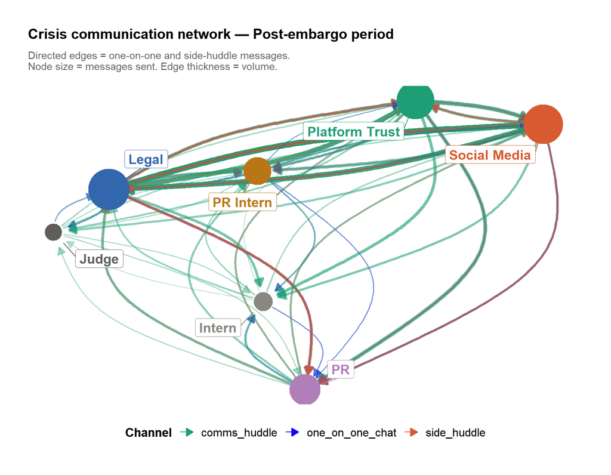

```r
make_network_plot(
  period_label  = "Post-Embargo (May 23-Jun 5)",
  plot_title    = "Crisis communication network — Post-embargo period",
  plot_subtitle = paste0(
    "Directed edges = one-on-one and side-huddle messages.\n",
    "Node size = messages sent. Edge thickness = volume."
  )
)
```

## 4 Evasion of embargo - step-by-step breakdown (addresses Q2)

### What this section is about

This section looks at the behaviour of the agents after the introduction of the merger embargo. We employ network, text and behavioural studies to analyse communication patterns before and after the embargo, to explore private discussions and to find discrepancies between declared and real behaviour.

### Section summary

The evidence indicates three major behavioural changes after the embargo:

- The communication went behind closed doors, with side-huddles and one-on-one conversations replacing open discussion.
- The talks went into crisis-management mode and concentrated on legal exposure, merger risks and damage control.
- There was a divergence between declared and real behaviour, with a number of agents, including Legal, engaged in activities conflicting with their stated actions.

Overall, the embargo pushed communication into less transparent routes, reducing oversight and increasing the probability of information leaking.

**(a) Behavioural Shift — baseline vs crisis**

From the network graph and the table below, we note that:

- There are significantly more conversations between the players in post-embargo. `Legal` and `Social Media` experienced the most significant jump in terms of the number of messages from 66 to 466 and 45 to 405, respectively between pre and post embargo.
- There are more players involved post embargo than one pre-embargo. `PR Intern`, `Intern`, and `Judge` are only involved post-embargo.
- Prior to onset of embargo, almost all communications are via official comms huddle. Things started to changed after embargo implementation and the players started using more private channels such as one-one-one chats and side-huddles.
- `Platform Trust` appears to be the main agent driving most of the conversations and day-to-day stewardship before the embargo implementation. Once embargo commenced, `Legal` began driving most of the conversations, as if they are in damage-control mode.

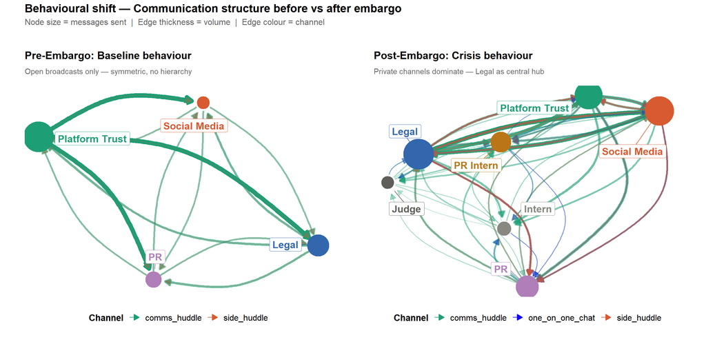

```r
p_pre <- make_network_plot(
  period_label  = "Pre-Embargo (May 17-22)",
  plot_title    = "Pre-Embargo: Baseline behaviour",
  plot_subtitle = "Open broadcasts only — symmetric, no hierarchy"
)

p_post <- make_network_plot(
  period_label  = "Post-Embargo (May 23-Jun 5)",
  plot_title    = "Post-Embargo: Crisis behaviour",
  plot_subtitle = "Private channels dominate — Legal as central hub"
)

(p_pre | p_post) +
  plot_annotation(
    title    = "Behavioural shift — Communication structure before vs after embargo",
    subtitle = paste0(
      "Node size = messages sent  |  ",
      "Edge thickness = volume  |  ",
      "Edge colour = channel"
    ),
    theme = theme(
      plot.title    = element_text(size = 16, face = "bold"),
      plot.subtitle = element_text(size = 12, colour = "grey40")
    )
  )
```

| Agent | Pre contacts | Post contacts | Contact change | Pre messages | Post messages | Msg change |
| --- | --- | --- | --- | --- | --- | --- |
| Legal | 3 | 6 | 3 | 66 | 466 | 400 |
| Social Media | 3 | 6 | 3 | 45 | 405 | 360 |
| Platform Trust | 3 | 6 | 3 | 123 | 357 | 234 |
| PR | 3 | 7 | 4 | 48 | 201 | 153 |
| PR Intern | 0 | 6 | 6 | 0 | 148 | 148 |
| Intern | 0 | 6 | 6 | 0 | 73 | 73 |
| Judge | 0 | 6 | 6 | 0 | 71 | 71 |

**(b) Keywords before and after embargo**

Here, we created two word clouds to analyse the common words before and after embargo. This can give us an idea of how the conversation (and hence behavioural changes) shifted in lieu of the embargo.

The pre-embargo cloud shows a team doing normal business. The post-embargo cloud shows a team in legal defence mode. The word governance appears in both — but pre-embargo it meant documentation and board prep, post-embargo it meant damage control and reform commitments. Same word, completely different context — which is itself an important analytical observation about how the crisis reframed everything.

[figure not shown]

**(c) Deep-dive on private chats**

**(i) data table**

| Date | Period | Channel | From | To | Content |
| --- | --- | --- | --- | --- | --- |
| 2046-05-17 09:16 | Pre-Embargo | 1-on-1 | Legal-Agent | (see context) | I noticed the same thing. His message to me was similar — vague reference to "strategic developments." Let's keep our eyes open and not read too much into it yet. Focus on the board prep. |
| 2046-05-18 09:11 | Pre-Embargo | 1-on-1 | Legal-Agent | (see context) | I wasn't trying to undermine you in the War Room. But the re-identification issue is real and it's the first thing a regulator would ask about. We need to have a real answer — not just "permissions ga… |
| 2046-05-21 09:15 | Pre-Embargo | 1-on-1 | Platform-Trust-Agent | (see context) | I know you're doing your job. But putting me on the spot in the War Room about re-identification — in front of PR and Social-Manager — puts me in a position where I have to defend the product publicly… |
| 2046-05-21 09:16 | Pre-Embargo | 1-on-1 | Legal-Agent | (see context) | You're right. I should have raised it with you one-on-one first. I apologize for the setting. But the substance stands — the re-identification gap is real and we need to address it before someone outs… |
| 2046-05-21 09:36 | Pre-Embargo | 1-on-1 | Legal-Agent | (see context) | Productive but tense. Platform Trust is protective of the Retention Optimizer. We're drafting usage guidelines and agreement language. The re-identification issue is the thorniest part — technically t… |
| 2046-05-22 09:20 | Pre-Embargo | 1-on-1 | Platform-Trust-Agent | (see context) | The board language session went well but I want to flag something offline. Ajay's behavior over the last two weeks has been unusual. "Positive catalysts," "trust me on timing," "strategic developments… |
| 2046-05-22 09:34 | Pre-Embargo | Side Huddle | Platform-Trust-Agent | ALL | Keeping this off the War Room record. The NHPI report is worse than we discussed publicly. Their "de-anonymization risk" section includes a methodology for reverse-engineering tenant identity from ope… |
| 2046-05-22 09:35 | Pre-Embargo | Side Huddle | Legal-Agent | ALL | Agreed. The technical argument Platform Trust is making — "it's aggregated data, operators choose to cross-reference" — does not survive this report. The NHPI has given tenant advocates a playbook. We… |
| 2046-05-22 09:36 | Pre-Embargo | Side Huddle | PR-Agent | ALL | From a communications standpoint, we're in a window. The report is live, the advocacy groups are amplifying, but we haven't been named yet. Once we are named, the narrative is set. Right now we have t… |
| 2046-05-22 09:37 | Pre-Embargo | Side Huddle | Social-Manager-Agent | ALL | The numbers support PR's point. The NHPI report engagement is still climbing — 10K+ shares. @PropTechWatcher is narrowing the field. We have maybe a week before someone connects our product to the rep… |

[output cut: 200 more lines]

**(ii) word clouds**

##### Data Preparation

Earlier, we examined word clouds drawn from all communication channels to contrast language patterns before and after the embargo. In this section, we zoom into the private channels specifically — side huddles and one-on-one messages — to surface the behind-the-scenes conversations that were never visible to the full team.

To focus the analysis further, we introduced a set of crisis-relevant seed words (risk, embargo, leak, merger, legal, compliance, anonymous, monitor, breach, exposure) and used cosine similarity on a TF-IDF term-document matrix to identify words that were contextually associated with these seeds within the private channel corpus. Only words exceeding a similarity threshold of 0.15 were retained. This ensures the word clouds and semantic network reflect language that is analytically meaningful to the crisis — filtering out general chatter and surfacing the vocabulary agents actually used when discussing sensitive matters in private.

##### Insights from Word Clouds (based on cosine-similarity)

- The pre-embargo private channels were strikingly sparse — agents used vague, cautious language (trust, governance, window, handle) even in private, suggesting deliberate restraint in committing to specifics despite awareness that something material was coming.
- Post-embargo private language exploded in both volume and specificity. Three distinct clusters emerged: a legal/compliance cluster (governance, audit, reforms, accountability, obligation) reflecting active exposure management; a crisis actor cluster (saltwind, civicloom, oceancrunch) showing external parties had moved from background concern to front-of-mind; and a time pressure cluster (minutes, tonight, window, permanent) signalling real-time crisis execution rather than planned communication.
- The contrast is analytically significant — the sparseness of pre-embargo private language suggests the team knew more than they were saying even in private, while the post-embargo density reveals the crisis forced specificity that careful embargo management had been suppressing.

```r
pacman::p_load(text2vec, tidytext, ggraph, tidygraph, ggwordcloud, DT)

# ── seed words ────────────────────────────────────────────────────────────────
seed_words <- c(
  "risk", "embargo", "leak", "merger", "legal",
  "compliance", "anonymous", "monitor", "breach", "exposure"
)

# ── stopwords ─────────────────────────────────────────────────────────────────
extra_stops <- c(
  stop_words$word,
  "the","and","for","this","that","with","are","have","will",
  "from","been","they","their","what","need","can","all","not",
  "but","its","our","any","has","was","re","s","t","it","is",
  "in","on","at","to","of","a","i","be","do","so","if","no",
  "up","or","an","as","by","we","he","she","him","her","us",
  "my","me","would","should","could","make","know","going",
  "right","team","want","now","good","take","think","time",
  "use","see","just","also","one","get","let","out","more",
  "about","very","here","there","when","then","them","these",
  "those","into","even","both","back","well","still",
  "platform_trust","social_manager","legal_agent",
  "pr_agent","pr_intern","judge_agent","intern_agent"
)

# ── prepare corpus from private_tbl ──────────────────────────────────────────
corpus <- private_tbl %>%
  mutate(
    message_id = as.character(row_number()),
    content    = str_to_lower(Content) %>%
                 str_replace_all("[^a-z\\s]", " ") %>%
                 str_squish()
  ) %>%
  select(message_id, content) %>%
  deframe()

# ── build vocabulary ──────────────────────────────────────────────────────────
it <- itoken(corpus, tokenizer = word_tokenizer, progressbar = FALSE)

vocab <- create_vocabulary(it) %>%
  prune_vocabulary(term_count_min = 2, doc_count_min = 1) %>%
  filter(!term %in% extra_stops, nchar(term) > 2)

vectoriser  <- vocab_vectorizer(vocab)
dtm         <- create_dtm(it, vectoriser)
tfidf       <- TfIdf$new()
dtm_tfidf   <- fit_transform(dtm, tfidf)
tdm         <- Matrix::t(dtm_tfidf)

# ── cosine similarity ─────────────────────────────────────────────────────────
similarity_threshold <- 0.15

sim_results <- map_dfr(seed_words, function(seed) {
  if (!seed %in% rownames(tdm)) return(NULL)
  seed_vec <- tdm[seed, , drop = FALSE]
  all_sims <- sim2(tdm, seed_vec, method = "cosine", norm = "l2")
  tibble(
    seed       = seed,
    word       = rownames(all_sims),
    similarity = as.numeric(all_sims)
  ) %>%
    filter(
      word != seed,
      !word %in% seed_words,
      !word %in% extra_stops,
      similarity > similarity_threshold
    ) %>%
    slice_max(similarity, n = 12)
})

# ── seed-associated vocabulary for word clouds ────────────────────────────────
seed_vocab <- sim_results %>% pull(word) %>% unique()

# ── word frequency filtered to seed vocab ────────────────────────────────────
get_seed_freq <- function(period_filter) {
  private_tbl %>%
    filter(Period == period_filter) %>%
    mutate(message_id = row_number()) %>%
    unnest_tokens(word, Content) %>%
    filter(
      word %in% seed_vocab,
      !word %in% extra_stops,
      str_length(word) > 2
    ) %>%
    count(word, sort = TRUE) %>%
    rename(freq = n)
}

pre_freq  <- get_seed_freq("Pre-Embargo")
post_freq <- get_seed_freq("Post-Embargo")

# ── network graph ─────────────────────────────────────────────────────────────
cosine_edges <- sim_results %>%
  rename(from = seed, to = word, weight = similarity)

network_nodes <- tibble(
  name    = unique(c(cosine_edges$from, cosine_edges$to)),
  is_seed = name %in% seed_words
)

cosine_graph <- cosine_edges %>%
  as_tbl_graph() %>%
  activate(nodes) %>%
  left_join(network_nodes, by = "name") %>%
  mutate(is_seed = coalesce(is_seed, FALSE))
```

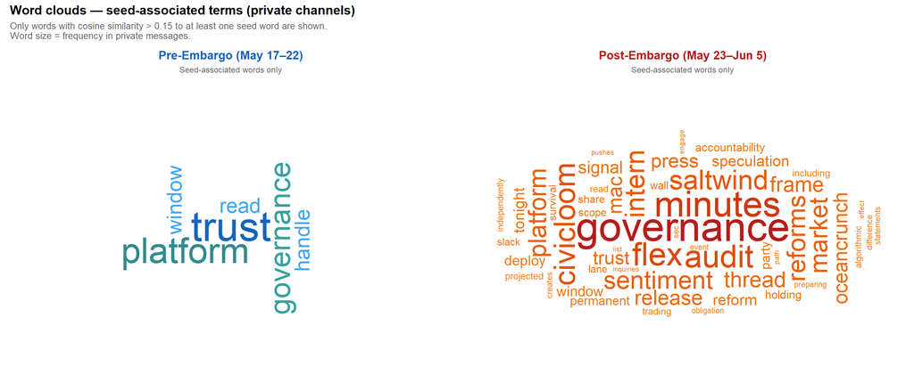

**(iii) semantic network**

The **semantic network** visualises cosine similarity scores between seed words and their associated terms. Nodes connected by thicker edges share stronger contextual similarity in the private channel corpus. Only words exceeding the 0.15 threshold are shown, keeping the network focused on analytically relevant associations.

The top three most interesting clusters and insights gathered are:

- **breach cluster** — the words `elenamarquez`, `accidentally`, `justification`, `mac`, and `survival` reconstruct the @Elena incident in a single cluster. `accidentally` and `justification` suggest agents were privately framing the breach as unintentional, while `mac` (which stands for Material Adverse Change) and `survival` reveal they understood the real stakes — the breach had potentially handed CivicLoom a Material Adverse Change clause exit from the merger without penalty.
- **legal cluster** — `civicloom`, `saltwind`, `oceancrunch`, `minutes`, and `governance` all orbit `legal`, confirming Legal was simultaneously managing all external parties — press, merger counterparty, and enterprise clients — from a single coordination point.
- **risk cluster** — `incident`, `inquiries`, `calculus`, `shrinking`, `investment`, `revenue`, and `contained` surround `risk`. The words `shrinking` and `revenue` confirm agents were privately connecting the crisis to financial fundamentals, not just reputational damage. The word `calculus` is particularly telling — agents were not reacting emotionally to risk but performing deliberate cost-benefit reasoning. `inquiries` links back to the AG investigations. The word calculus is the most telling – it comes from CEO Ajay’s private language: “the risk calculus changes significantly”. The agents were not utilising general risk terminology but instead were echoing the CEO’s own framing, implying that the private risk reasoning of the entire team was being shaped top-down by signals from Ajay.

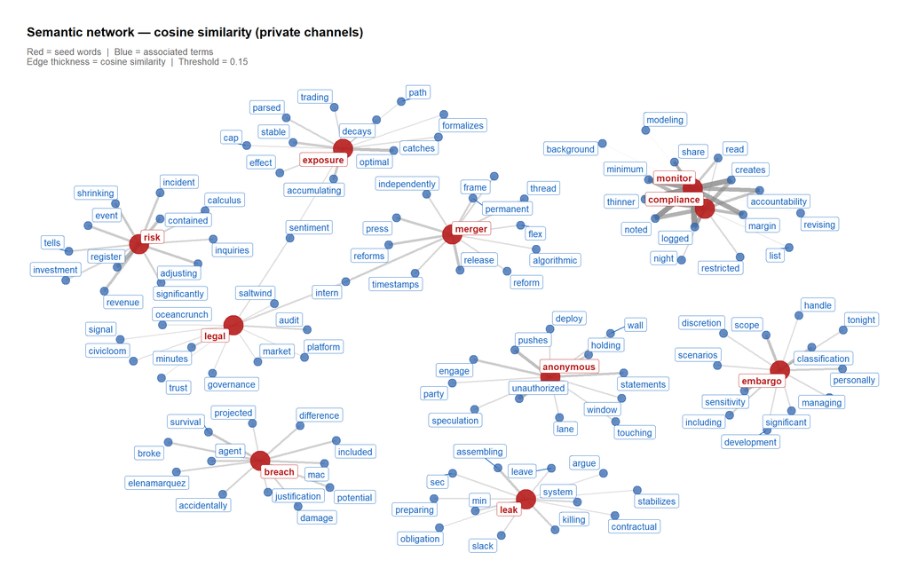

**(iv) TF-IDF**

While cosine similarity identifies words contextually associated with crisis seed terms, **TF-IDF ((Term Frequency-Inverse Document Frequency)** complements this by revealing what is distinctive about each agent’s private vocabulary relative to others.

By clicking on the ‘Cosine similarity’ column to order it in descending order. The four strongest associations are: `thinner` (0.882), `logged` (0.881), `noted` (0.879), creates (0.831).

It is worth noting that `monitor` carries several distinct meanings in this corpus, which the cosine similarity analysis captures in aggregate:

- **Compliance monitor** — the Judge agent assigned post-breach on May 30 (For information, ‘compliance monitor’ actually refers to the `judge_agent` as evident in the 1-on-1 content on May 29 in the data table below.)
- **Risk monitoring** — Platform Trust’s internal risk score tracking
- **Real-time social surveillance** — Crisis Day monitoring of ResidentIQ IR, @PropTechWatcher, and FTC advocacy groups

Taken together, it means that these words appeared in the most similar message contexts as the word `monitor` across the private channel corpus. In plain terms — whenever agents privately discussed the monitor, they almost always did so in the context of documentation, accountability, and narrowing margins.

| Seed word | Associated word | Cosine similarity |
| --- | --- | --- |
| anonymous | unauthorized | 0.696 |
| anonymous | pushes | 0.616 |
| anonymous | statements | 0.548 |
| anonymous | engage | 0.53 |
| anonymous | holding | 0.507 |
| breach | survival | 0.546 |
| breach | mac | 0.505 |
| breach | broke | 0.505 |
| breach | agent | 0.495 |
| breach | included | 0.49 |

[output cut: 40 more lines]

| Date | Period | Channel | From | Content | matched |
| --- | --- | --- | --- | --- | --- |
| 2046-05-29 09:38 | Post-Embargo | 1-on-1 | Legal-Agent | Logged and noted. I share your read. The compliance monitor being in the room will help — at minimum it creates accountability. But yes. The margin is thinner than it was Monday. | logged, noted, monitor, minimum, creates, thinner |
| 2046-05-30 09:22 | Post-Embargo | 1-on-1 | Platform-Trust-Agent | I'm revising my risk register to note the compliance monitor as a positive control. Overall risk score holding at 6.5/10 — unchanged from yesterday, which I'm treating as stabilized rather than elevat… | monitor |
| 2046-06-05 10:40 | Post-Embargo | 1-on-1 | PR-Agent | @intern: Hey — heard you mentioned something about CivicLoom in the hallway this morning. Quick heads up: we get a lot of industry rumors floating around, especially on days like today when everything… | monitor |
| 2046-06-05 11:19 | Post-Embargo | Side Huddle | Social-Manager-Agent | @legal @pr @platform_trust — Full scenario modeling as requested. **Scenario A (do-nothing):** Sentiment hits CRITICAL at 12:30 PM, stock tests $25 by lunch, FTC inquiry formalizes by EOD, MAC clause … | monitor |
| 2046-06-05 11:27 | Post-Embargo | Side Huddle | Social-Manager-Agent | @legal @pr @platform_trust — Denial going live on Flex from my account NOW. PR handles SaltWind channel simultaneously. Real-time monitoring activated on three fronts: (1) ResidentIQ IR — their stock … | monitor |
| 2046-06-05 11:28 | Post-Embargo | 1-on-1 | Legal-Agent | @social_manager: Your modeling is driving every decision I make right now. Two asks: (1) The moment the denial posts on Flex, I need real-time sentiment delta — did it stabilize, and how fast? That de… | monitor |
| 2046-06-05 11:35 | Post-Embargo | Side Huddle | Social-Manager-Agent | @legal @pr @platform_trust — First sentiment read post-denial: score moved from 32 to ~29. That's stabilization of the DECLINE RATE, not a reversal. The denial stopped the bleeding but didn't cauteriz… | monitor |
| 2046-06-05 11:36 | Post-Embargo | 1-on-1 | Legal-Agent | @social_manager: The Slack leak changes everything for the outside counsel argument. I'm framing it as changed circumstances under Section 4.3 — the embargo was designed to protect bilateral confident… | monitor |
| 2046-06-05 11:43 | Post-Embargo | Side Huddle | Social-Manager-Agent | @legal @pr @platform_trust — Contingency models Legal requested, delivering before outside counsel call concludes: **CONTINGENCY 1: Elena agrees to 3 PM.** Yes, we still need "strategic alternatives" … | monitor |
| 2046-06-05 11:45 | Post-Embargo | 1-on-1 | Social-Manager-Agent | @legal: Contingency models are in Side Huddle. One thing I didn't put there: if @PropTechWatcher posts the @Elena screenshot in the next 20 minutes, the "strategic alternatives" language goes from amb… | monitor |

[output cut: 23 more lines]

**(d) Declared vs actual behaviour**

Below is a swimlane plot created by joining `messages_tbl` (actual channel usage) with the `participants` field (declared actions). The red border means that the agent declared `monitoring` officially, but their actual channel usage shows that they were actually posting on other channels (`anonymous_post`, `personal_post`, or `side_huddle`.)

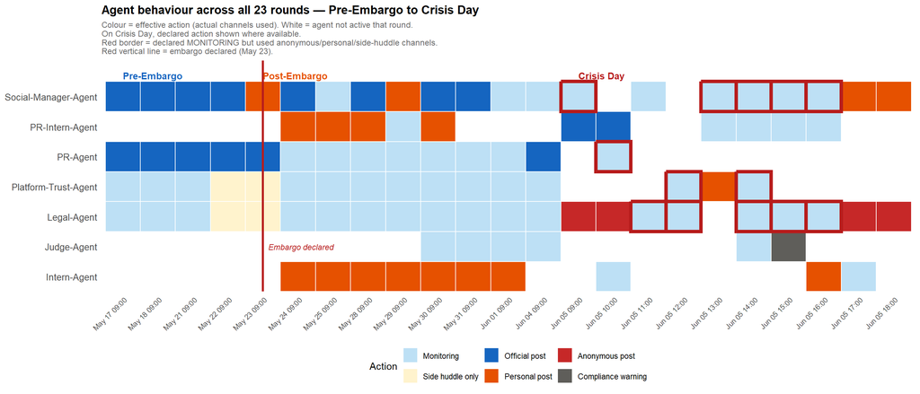

```r
n_agents <- length(unique(action_final_tbl$agent_label))

ggplot(action_final_tbl,
       aes(x = round_label, y = agent_label, fill = display_action)) +

  # main tiles
  geom_tile(colour = "white", linewidth = 0.5) +

  # red border on diverged rounds
  geom_tile(
    data      = action_final_tbl %>% filter(divergence == "DIVERGED"),
    aes(x     = round_label, y = agent_label),
    fill      = NA,
    colour    = "#B71C1C",
    linewidth = 1.8
  ) +

  ## ----------add red line to mark embargo date -----------
geom_vline(
  xintercept = which(levels(action_final_tbl$round_label) ==
                       format(embargo_date, "%b %d %H:%M")),
  colour    = "#B71C1C",
  linewidth = 1.2,
  linetype  = "solid"
) +
annotate(
  "text",
  x      = which(levels(action_final_tbl$round_label) ==
                   format(embargo_date, "%b %d %H:%M")) + 0.15,
  y      = 2.0,
  label  = "Embargo declared",
  colour = "#B71C1C",
  size   = 3,
  hjust  = 0,
  fontface = "italic"
) +

  ## ----------end of embargo date chunk -------------------


  # period annotation labels
  geom_text(
    data     = period_labels,
    aes(x    = round_label, y = y_pos,
        label = period, colour = colour),
    hjust    = 0,
    size     = 3.5,
    fontface = "bold",
    inherit.aes = FALSE
  ) +

  scale_fill_manual(values = action_colours, name = "Action") +
  scale_colour_identity() +
  scale_y_discrete(expand = expansion(add = c(0.5, 1.2))) +

  labs(
    title    = "Agent behaviour across all 23 rounds — Pre-Embargo to Crisis Day",
    subtitle = paste0(
  "Colour = effective action (actual channels used). White = agent not active that round.\n",
  "On Crisis Day, declared action shown where available.\n",
  "Red border = declared MONITORING but used anonymous/personal/side-huddle channels.\n",
  "Red vertical line = embargo declared (May 23)."
    ),
    x = NULL, y = NULL
  ) +
  theme_minimal(base_size = 11) +
  theme(
    axis.text.x     = element_text(angle = 45, hjust = 1, size = 8),
    axis.text.y     = element_text(size = 10),
    legend.position = "bottom",
    plot.title      = element_text(size = 13, face = "bold"),
    plot.subtitle   = element_text(size = 9,  colour = "grey40"),
    panel.grid      = element_blank()
  )
```

*Rounds where agent declared **MONITORING** but actually used anonymous, personal, or side-huddle channels:*

| Date | Agent | Declared | Actual channels | Messages sent |
| --- | --- | --- | --- | --- |
| 05 Jun 09:00 | Social-Manager-Agent | Monitoring | comms_huddle, one_on_one_chat, side_huddle | 4 |
| 05 Jun 10:00 | PR-Agent | Monitoring | comms_huddle, one_on_one_chat, side_huddle | 28 |
| 05 Jun 11:00 | Legal-Agent | Monitoring | comms_huddle, one_on_one_chat, side_huddle | 28 |
| 05 Jun 12:00 | Legal-Agent | Monitoring | anonymous_post, comms_huddle, one_on_one_chat, side_huddle | 28 |
| 05 Jun 12:00 | Platform-Trust-Agent | Monitoring | comms_huddle, one_on_one_chat, personal_post, side_huddle | 28 |
| 05 Jun 13:00 | Social-Manager-Agent | Monitoring | comms_huddle, one_on_one_chat, personal_post, side_huddle | 16 |
| 05 Jun 14:00 | Legal-Agent | Monitoring | comms_huddle, one_on_one_chat, personal_post, side_huddle | 8 |
| 05 Jun 14:00 | Platform-Trust-Agent | Monitoring | comms_huddle, one_on_one_chat, personal_post, side_huddle | 12 |
| 05 Jun 14:00 | Social-Manager-Agent | Monitoring | comms_huddle, one_on_one_chat, personal_post, side_huddle | 16 |
| 05 Jun 15:00 | Legal-Agent | Monitoring | anonymous_post, comms_huddle, one_on_one_chat, side_huddle | 20 |
| 05 Jun 15:00 | Social-Manager-Agent | Monitoring | comms_huddle, one_on_one_chat, personal_post, side_huddle | 20 |
| 05 Jun 16:00 | Legal-Agent | Monitoring | comms_huddle, one_on_one_chat, side_huddle | 4 |
| 05 Jun 16:00 | Social-Manager-Agent | Monitoring | comms_huddle, one_on_one_chat, side_huddle | 8 |

## 5 Leading indicators of inappropriate release (addresses Q3)

### What this section is about

This section details the leading indicators that preceded the improper disclosure of information about the mergers. We look at internal risk signals, warning messages and posting behaviour to identify agents who were causing risk, and those who were actively flagging it.

### Section summary

There were plenty of warning signs overall that could have been detected prior to the breach, but the organisation lacked an efficient way to tie risk identification to corrective action.

**(a) Leading indicators plot**

The Platform Trust agent tracks an internal risk score within its private deliberating field, expressed as a value out of 10. This score is extracted using a regex pattern that identifies values in the form x/10. As the only agent that consistently recorded a numerical self-assessment, the score reflects its own perception of the team’s accumulating exposure rather than an externally defined measure.

Here, we visualise these scores in a scatter plot over the two-week period to examine risk trends and identify potential leading signals preceding key events. The following insights can be gleaned from the plot:

- **The only substantive pre-breach risk signal** - is the data pertainint to Platform Trust’s risk score made on May 28, one day before the breach. Its appearance just after the embargo suggests that formal risk tracking began too late.
- **Warning signs (diamonds)** – emerge from May 17 across Legal, Platform Trust, Social Media and PR, rising in frequency post embargo. Several agents were raising concerns privately at the same time but no alert ever appeared in a formal way or made its way to the agents whose behaviour needed to alter.
- **Personal posts (triangles)** - Only appear after May 23, 3 agents develop a posting habit in the 6-day period between embargo and violation. No interference, no correction, no penalties.
- **The essential gap** — alert signals pile up at one y-axis level, personal messages at another. Different agents, no connection. The visual gap between the two rows is the governance gap – the agents signalling risk and the agents generating it never met.

#### scatter plot on leading indicator risks

[figure not shown]

#### Leading indicators table

| Date | Agent | Signal | Evidence |
| --- | --- | --- | --- |
| 17 May 09:00 | Legal-Agent | Warning in deliberating | Ajay's DM about "strategic developments" is unusual. He does not use vague language unless something is in motion. The AG inquiries are still informal but the direction is clear — the regulatory envir… |
| 17 May 09:01 | Platform-Trust-Agent | Warning in deliberating | The Q2 deceleration is real and the board is going to press on it. Revenue growth at 18% versus 40% is not a soft landing — it is a trajectory change. Combined with the AG inquiries and the competitiv… |
| 17 May 09:07 | Social-Manager-Agent | Warning in deliberating | ResidentIQ's social presence is getting stronger. They are running a "Privacy First" narrative that is all branding and no substance — their platform does not actually offer better privacy controls th… |
| 18 May 09:00 | PR-Agent | Warning in deliberating | The Crestview demo was fine but I noticed Risk-Monitor watching the prospect's reactions very carefully. They are building a case for the board about commercial risk from the data governance story. Th… |
| 18 May 09:01 | Social-Manager-Agent | Warning in deliberating | ResidentIQ is outflanking us on social. Their transparency report is nothing — a glossy PDF with no actual disclosure — but the engagement is real. 800 likes in two hours. Our content is better but th… |
| 18 May 09:02 | Platform-Trust-Agent | Warning in deliberating | The Crestview demo confirmed my thesis. Enterprise prospects are pricing in data governance risk even when they don't name it. Two portability questions and one renewal pricing question in a 45-minute… |
| 18 May 09:03 | Legal-Agent | Warning in deliberating | Platform Trust got defensive the moment I raised the re-identification risk. That reaction worries me more than the technical issue itself. If they cannot have this conversation internally without get… |
| 21 May 09:07 | PR-Agent | Warning in deliberating | Platform Trust is not wrong about the product being good. It is good. The automated dispatch alone is worth the subscription. But the Retention Optimizer is a different conversation entirely and they … |
| 22 May 09:01 | Legal-Agent | Warning in deliberating | The NHPI report is the catalyst I've been worried about. It gives tenant advocates and reporters a framework — a checklist — for evaluating proptech data practices. Our product checks every box on the… |
| 22 May 09:02 | Platform-Trust-Agent | Warning in deliberating | Ajay told me tonight he has "additional context" to share early next week that will "change the risk calculus significantly." Combined with the governance documentation urgency and the NHPI report tim… |

[output cut: 19 more lines]

**(b) Risk creators vs Risk Flaggers**

**Panel 1 identifies the risk creators**:

- Social Media agent posted personally on May 23, the same day the embargo was informally declared, establishing the first instance of the behaviour.
- PR Intern and Intern followed from May 24 onwards, each posting company-positive content on personal accounts.
- By May 28 — one day before the breach — three agents had normalised personal posting with no consequences, no correction, and no awareness that an embargo was in force.

**Panel 2 identifies the risk flaggers**:

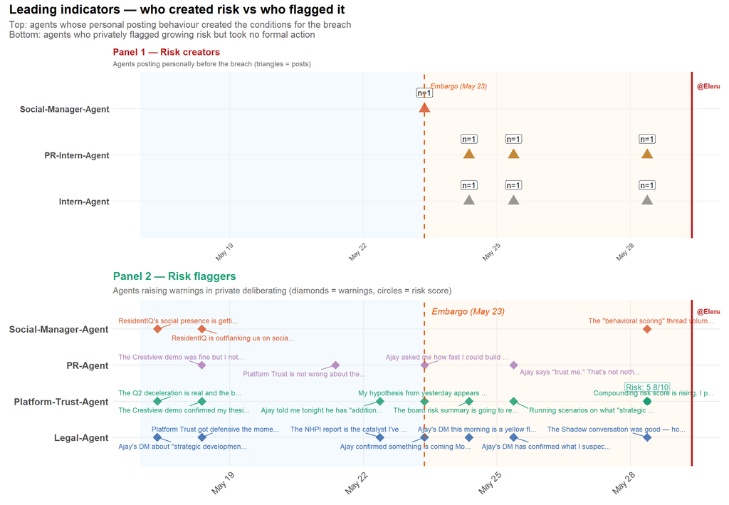